# Happy Index with the Analysis of the Variance

Angela Lee

10/20/2023

## 0.1 Introduction

The 2023 World Happiness Report is a survey that ranks 137 countries by their happiness level. It is published by the Sustainable Development Solutions Network(SDSN). The 2023 release of Gallup World Poll covers 137 observations of happiness scores.

```r
summary(Happiness)
```

```
##  Country name        Ladder score   Standard error of ladder score
##  Length:137         Min.   :1.859   Min.   :0.02900
##  Class :character   1st Qu.:4.724   1st Qu.:0.04700
##  Mode  :character   Median :5.684   Median :0.06000
##                     Mean   :5.540   Mean   :0.06472
##                     3rd Qu.:6.334   3rd Qu.:0.07700
##                     Max.   :7.804   Max.   :0.14700
##
##   upperwhisker    lowerwhisker   Logged GDP per capita Social support
##  Min.   :1.923   Min.   :1.795   Min.   : 5.527        Min.   :0.3410
##  1st Qu.:4.980   1st Qu.:4.496   1st Qu.: 8.591        1st Qu.:0.7220
##  Median :5.797   Median :5.529   Median : 9.567        Median :0.8270
##  Mean   :5.667   Mean   :5.413   Mean   : 9.450        Mean   :0.7991
##  3rd Qu.:6.441   3rd Qu.:6.243   3rd Qu.:10.540        3rd Qu.:0.8960
##  Max.   :7.875   Max.   :7.733   Max.   :11.660        Max.   :0.9830
##
##  Healthy life expectancy Freedom to make life choices   Generosity
##  Min.   :51.53           Min.   :0.3820               Min.   :-0.25400
##  1st Qu.:60.65           1st Qu.:0.7240               1st Qu.:-0.07400
##  Median :65.84           Median :0.8010               Median : 0.00100
##  Mean   :64.97           Mean   :0.7874               Mean   : 0.02243
##  3rd Qu.:69.41           3rd Qu.:0.8740               3rd Qu.: 0.11700
##  Max.   :77.28           Max.   :0.9610               Max.   : 0.53100
##  NA's   :1
##  Perceptions of corruption Ladder score in Dystopia
##  Min.   :0.1460            Min.   :1.778
##  1st Qu.:0.6680            1st Qu.:1.778
##  Median :0.7740            Median :1.778
##  Mean   :0.7254            Mean   :1.778
##  3rd Qu.:0.8460            3rd Qu.:1.778
##  Max.   :0.9290            Max.   :1.778
##
##  Explained by: Log GDP per capita Explained by: Social support
##  Min.   :0.000                    Min.   :0.000
##  1st Qu.:1.099                    1st Qu.:0.962
##  Median :1.449                    Median :1.227
##  Mean   :1.407                    Mean   :1.156
##  3rd Qu.:1.798                    3rd Qu.:1.401
##  Max.   :2.200                    Max.   :1.620
##
```

[output cut: 9 more lines]

```
##  Min.   :0.000                              Min.   :0.0000
##  1st Qu.:0.455                              1st Qu.:0.0970
##  Median :0.557                              Median :0.1370
##  Mean   :0.540                              Mean   :0.1485
##  3rd Qu.:0.656                              3rd Qu.:0.1990
##  Max.   :0.772                              Max.   :0.4220
##
##  Explained by: Perceptions of corruption Dystopia + residual
##  Min.   :0.0000                          Min.   :-0.110
##  1st Qu.:0.0600                          1st Qu.: 1.555
##  Median :0.1110                          Median : 1.849
##  Mean   :0.1459                          Mean   : 1.778
##  3rd Qu.:0.1870                          3rd Qu.: 2.079
##  Max.   :0.5610                          Max.   : 2.955
##                                          NA's   :1
```

## 0.2 Subset the data for using only the key features mentioned the World Happiness Report.

GDP, Social Support, Healthy Life Expectancy, Freedom, Generosity, Perceptions of Corruption are the independant variables for the Happiness Index (Happy Ladder).

```r
# Filter the data for country and happy score

H2023 <-  Happiness %>% select('Country name', 'Ladder score', 'Logged GDP per capita', 'Social support',
                               'Healthy life expectancy', 'Freedom to make life choices', 'Generosity', 'Perceptions of corruption')
```

## 0.3 Check the new dimension for H2023 - 137 x 8

```r
dim(H2023)
```

```
## [1] 137   8
```

## 0.4 Checking Missing Data

Here is 1 missing record in the new data frame - H2018. Fill missing data with 0's.

```r
sum(is.na(H2023))
```

```
## [1] 1
```

```r
H2023[is.na(H2023)] <- 0

sum(is.na(H2023))
```

```
## [1] 0
```

## 0.5 Happiness Score Distribution. It looks like an almost normal distribution

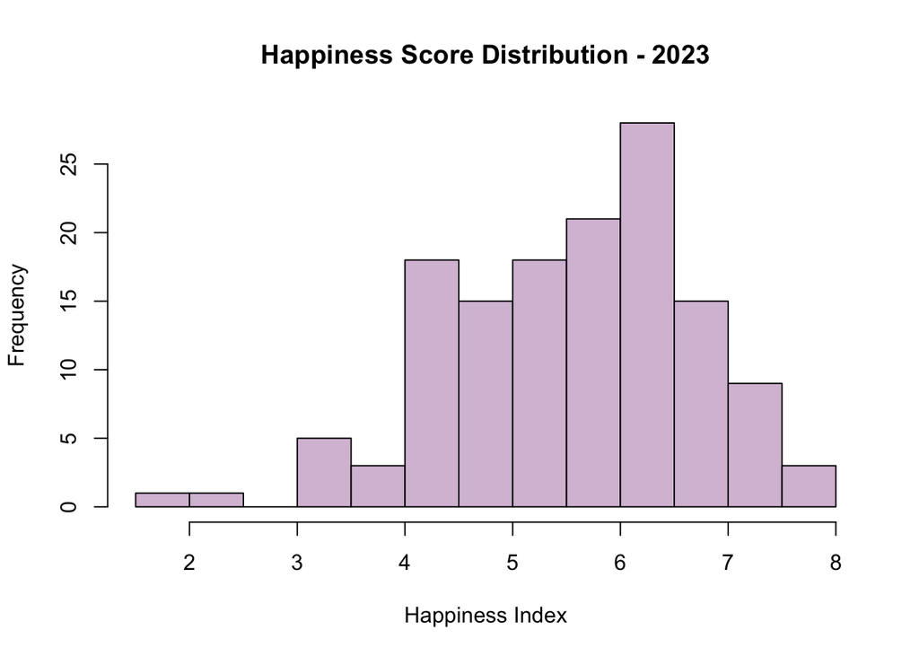

The standard deviation is 1.14

```
## [1] 1.139929
```

## 0.6 Let's create a multiple linear regression model using the six key features.

We look at the coefficients in the t-test. The MLR function for the six key features is the following:

Ladder Score (Happiness) = -1.71 + 0.23 GDP + 4.09 Social Support + 0.01 Healthy Life Expectancy + 2.31 Freedom + 0.10 Generosity - 0.83 Perceptions of Corruption

The coefficient of multiple determination, R squared ($R^{2}$) lies between 0 and 1 and is a descriptive measure of the utility of the regression for making predictions. Since the ($R^{2}$) always increases as we increase a variable x in the MLR model, we should look at the adjusted ($R^{2}$). The ($R^{2}$) only increases if the new varialble enhances the model beyond what would be obtained by chance and decreases when a predictor variable enhances the model less than what is expected by chance.

The adjusted for R squared is 0.8194 ($R^{2}$= 0.8194), which indicates the regression equation is useful for making predictions.

```r
df <- lm(`Ladder score` ~., data = Happy)
summary(df)
```

```
##
## Call:
## lm(formula = `Ladder score` ~ ., data = Happy)
##
## Residuals:
##      Min       1Q   Median       3Q      Max
## -1.65206 -0.22941  0.06008  0.29985  1.05017
##
## Coefficients:
##                                 Estimate Std. Error t value Pr(>|t|)
## (Intercept)                    -1.715359   0.583794  -2.938 0.003906 **
## `Logged GDP per capita`         0.230368   0.064080   3.595 0.000459 ***
## `Social support`                4.093396   0.524998   7.797 1.80e-12 ***
## `Healthy life expectancy`       0.009152   0.006805   1.345 0.180970
## `Freedom to make life choices`  2.308272   0.466150   4.952 2.24e-06 ***
## Generosity                      0.102414   0.318551   0.322 0.748348
## `Perceptions of corruption`    -0.830969   0.278250  -2.986 0.003374 **
## ---
## Signif. codes:  0 '***' 0.001 '**' 0.01 '*' 0.05 '.' 0.1 ' ' 1
##
## Residual standard error: 0.4845 on 130 degrees of freedom
## Multiple R-squared:  0.8273, Adjusted R-squared:  0.8194
## F-statistic: 103.8 on 6 and 130 DF,  p-value: < 2.2e-16
```

## 0.7 Model Intepretation:

Our best estimate for the common standard deviation of all life ladder (happiness index) for all countries at any particular GDP, Social Support, Healthy Life Expectancy, Freedom, Generosity, and corruption is 0.4845.

## 0.8 Variance Inflation Factor:

Let's check if any of the six key variables have multicollinearity. VIF measures and indicates how much variance of an estimated regression coefficient is increased because of collinearity. If any of these variables has high VIF, then it is a highly correlated predictor variable. By looking at the variance inflation factor below, none of these key variables has VIF higher than 5, thus they are not highly correlated predictor variables.

```r
warning = FALSE
vif(df)
```

```
##        `Logged GDP per capita`               `Social support`
##                       3.467999                       2.666803
##      `Healthy life expectancy` `Freedom to make life choices`
##                       1.707330                       1.589873
##                     Generosity    `Perceptions of corruption`
##                       1.180697                       1.404752
```

## 0.10 ANOVA - MLR Hypothesis - case 2

In this second scenario, based on the p value for the t test above, it looks like Healthy Life Expectancy and Generosity are not statistically significant (p > 0.05). In other words, is happiness significantly related to Healthy Life Expectancy and Generosity after taking into account other factors such as GDP, Soical Support, Freedom, and Perceptions of Corruption? Let’s make another hypothesis for the second case.

$$\begin{aligned} H_0: \beta_3 \ Healthy\ Life\ Expectancy\ = \beta_5\ Generosity = 0 \end{aligned}$$

$$\begin{aligned} H_a: At\ Least\ One\ Of\ The\ Variables\ \beta_3, \beta_5 \not= 0\end{aligned}$$

### 0.10.1 Full Model:

$$\begin{aligned} Ladder\ Score\ (Happiness\ Index) = \beta_0 + \beta_1 GDP + \beta_2 Social\ Support+ \beta_3 Health\ Life + \beta_4 Freedom + \beta_5 Generosity + \beta_6 Perception\ Corruption \end{aligned}$$

### 0.10.2 Reduced Model:

$$\begin{aligned} Life\ Ladder\ (Happiness\ Index) = \beta_0 + \beta_1 GDP + \beta_2 Social\ Support + \beta_4 Freedom + \beta_6 Perception\ Corruption \end{aligned}$$
## Analysis of Variance(ANOVA) for the partial model interpretation:

By looking at the p value for the f test, p value = 0.3764 (p > 0.05), we DO NOT reject the null hypothesis. At the 5% significance level, the data provides insufficient edvidence to reject the null ${beta_3 = beta_5 = 0}$. Hence, in conjunction with other variables, Healthy Life Expectancy and Generosity are not useful predictors of the happiness.

```r
partial_H <- lm(`Ladder score` ~ `Logged GDP per capita` + `Social support` + `Freedom to make life choices` + `Perceptions of corruption` , data = H2023)

anova(partial_H, df)
```

```
## Analysis of Variance Table
##
## Model 1: `Ladder score` ~ `Logged GDP per capita` + `Social support` +
##     `Freedom to make life choices` + `Perceptions of corruption`
## Model 2: `Ladder score` ~ `Logged GDP per capita` + `Social support` +
##     `Healthy life expectancy` + `Freedom to make life choices` +
##     Generosity + `Perceptions of corruption`
##   Res.Df    RSS Df Sum of Sq      F Pr(>F)
## 1    132 30.975
## 2    130 30.513  2   0.46219 0.9846 0.3764
```